# Agkistrodon Distribution in Southeastern United States

Jack Kauphusman

11/6/2019

# 1 General Introduction

Snake research has been a growing topic, specifically in ecological studies that help to identify snakes roles in ecological systems (Steen et al. 2014). Since snakes are secretive in nature, ecological studies very in number for investigation of certain species. The subfamily Crotalinae contains the pit-viper snakes of the Americas, and has received much attention in research regarding ecology (Douglas et al. 2009, Lomonte et al. 2014) . The pit-vipers of that reside in North America are the Agkistrodon and rattlesnakes (Crotalus and Sistrurus) (Guiher and Burbrink 2008). Ecological research in Agkistrodon has been extensive in some species and very limited in others (Burchfield 1982).

The species that are among Agkistrodon are A. piscivorus (cottonmouth), A. contrortrix (copperhead), and the cantils (A. taylorii, A. bilineatus, A. russeolus , and A. howardgloydi). Geographically, copperheads and cottonmouths are located in the southeast United States, while the cantils are located throughout Central America (Parkinson et al. 2000, Porras et al. 2013).

Below, I will be investigating the distribution the genus Agkistrodon throughout the southeastern United States.

# 2 DISMO on Agkistrodon in the U.S.

DISMO is a package from R that allows one to use the datasets from GBIF|Global Biodiversity Information Facility (https://www.gbif.org/), which can be very useful to creat distribution maps of species occurences.

I will be investigating the distribution between cottonmouths (A. piscivorus) and copperheads (A. contortrix) throughout the southeastern United State.

**Records of cottonmouth data from GIF.**

```r
extent <- extent(-94,-78,25,40)

agk_dismo <- gbif("agkistrodon", species = "piscivorus", ext = extent,
             geo = TRUE, sp = TRUE, download = TRUE,
             removeZeros = TRUE)
```

```
3282 records found
0-300-600-900-1200-1500-1800-2100-2400-2700-3000-3282 records downloaded
```

```r
agk_xy <- as.data.frame(cbind(agk_dismo@coords[,1],agk_dismo@coords[,2]))
colnames(agk_xy) <- c("longitude","latitude")

agk_xy<-cbind(agk_xy, data.frame("Species" = "Cottonmouth"))
```

**Records of copperhead data from GIF.**

```r
cont_dismo <- gbif("agkistrodon", species = "contortrix", ext = extent,
             geo = TRUE, sp = TRUE, download = TRUE,
             removeZeros = TRUE)
```

```
2508 records found
0-300-600-900-1200-1500-1800-2100-2400-2508 records downloaded
```

```r
cont_xy <- as.data.frame(cbind(cont_dismo@coords[,1],cont_dismo@coords[,2]))
colnames(cont_xy) <- c("longitude","latitude")
cont_xy<-cbind(cont_xy, data.frame("Species" = "Copperhead"))
```

# 3 Distribution Map

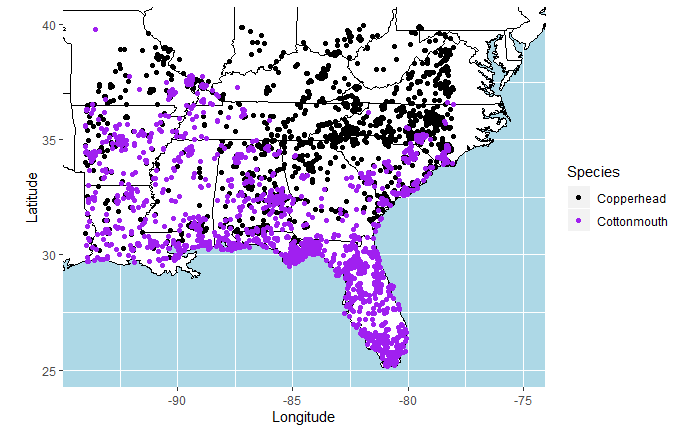

```r
snake_xy<-rbind(cont_xy, agk_xy)
us <- map_data("state")

ggplot(data = snake_xy, aes(x=longitude, y=latitude)) +
  geom_polygon(data = us, aes(x=long, y = lat, group = group),
               fill = "white", color="black") +
  geom_point(aes(color = Species)) +
  scale_color_manual(values = c("black", "purple"))+
  xlab("Longitude") +
  ylab("Latitude") +
  coord_fixed(xlim = c(-94,-75), ylim = c(25,40))+
  theme(panel.background = element_rect(fill = "lightblue"))
```

There is extensive overlab between the sister species, but you can see that copperheads prefer higher latitudes, while cottonmouths tend to stay near the lower latitudes.

# 4 Elevation

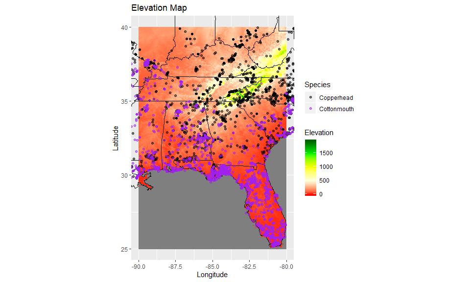

```r
srtm1<-getData(name = "SRTM", lat = 35, lon = -85, path = "./Data")
srtm2<-getData(name = "SRTM", lat = 35, lon = -90, path = "./Data")
srtm3<-getData(name = "SRTM", lat = 40, lon = -85, path = "./Data")
srtm4<-getData(name = "SRTM", lat = 40, lon = -90, path = "./Data")
srtm5<-getData(name = "SRTM", lat = 30, lon = -85, path = "./Data")
srtm6<-getData(name = "SRTM", lat = 30, lon = -90, path = "./Data")
mosaic_strm<-mosaic(srtm1,srtm2,srtm3, srtm4,srtm5,srtm6, fun = mean)

gplot(mosaic_strm) +
  geom_raster(aes(fill=value)) +
   scale_fill_gradientn(colours=c("red","lightyellow", "yellow","green","darkgreen"), "Elevation")+
  geom_polygon(data = us, aes(x= long, y = lat, group = group),
               fill = NA, color="black")+
  coord_fixed(xlim = c(-80,-90), ylim = c(25,40))+
  geom_point(data = snake_xy,aes(x = longitude, y = latitude,color = Species), alpha = 0.5)+
    scale_color_manual(values = c("black", "purple"))+
  xlab("Longitude")+
  ylab("Latitude")+
  ggtitle("Elevation Map")
```

**Map 2:** Cottonmouth and copperhead distribution along an elevation map of the southeastern United States.

Based on observations from Map 2, one can observe that cottonmouths tend to avoid higher elevation.

# 5 Climate Variables

Below, I performed probability distribution maps from both the cottonmouth and copperhead species, to see to what affect climate had on identifying the snakes probability of occurance.

```r
bioclim <- getData(name = "worldclim", res = 2.5, var = "bio", path = "./Data")

names(bioclim) <- c("Ann Mean Temp","Mean Diurnal Range","Isothermality","Temperature Seasonality",
                           "Max Temp Warmest Mo","Min Temp Coldest Mo","Ann Temp Range","Mean Temp Wettest Qtr",
                           "Mean Temp Driest Qtr","Mean Temp Warmest Qtr","Mean Temp Coldest Qtr","Annual Precip",
                           "Precip Wettest Mo","Precip Driest Mo","Precip Seasonality","Precip Wettest Qtr",
                           "Precip Driest Qtr","Precip Warmest Qtr","Precip Coldest Qtr")

bio_extent <- extent(x = c(
  min(agk_xy$longitude),
  max(agk_xy$longitude),
  min(agk_xy$latitude),
  max(agk_xy$latitude)))

bioclim_extent <- crop(x = bioclim, y = bio_extent)
bioclim_model <- bioclim(x = bioclim_extent, p = agk_xy[,1:2])
presence_model <- dismo::predict(object = bioclim_model,
                                 x = bioclim_extent,
                                 ext = bio_extent)
```

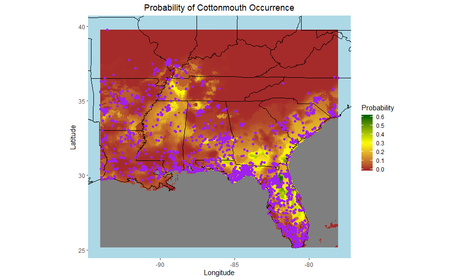

```r
gplot(presence_model) +
  geom_raster(aes(fill=value)) +
  geom_polygon(data = us, aes(x= long, y = lat, group = group),
               fill = NA, color="black") +
  geom_point(data = agk_xy, aes(x = longitude, y = latitude), color = "purple", alpha = 1) +
  scale_fill_gradientn(colours=c("brown","yellow","darkgreen"), "Probability") +
  coord_fixed(xlim = c(max(snake_xy$longitude),min(snake_xy$longitude)), ylim = c(min(snake_xy$latitude),max(snake_xy$latitude))) +
  xlab("Longitude") + ylab("Latitude") + ggtitle("Probability of Cottonmouth Occurrence") +
  theme(panel.background = element_rect(fill = "lightblue"))+ theme(plot.title = element_text(hjust = 0.5)) + theme(legend.position = "right")+
  theme(panel.grid.major = element_blank(),
        panel.grid.minor = element_blank())
```

**Map 3:** Probabilitiy of occurence of cottonmouths using climatic variables.

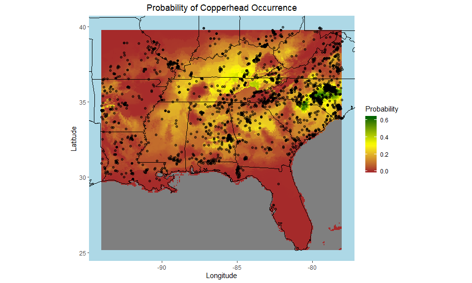

```r
bioclim_model1 <- bioclim(x = bioclim_extent, p = cont_xy[,1:2])
presence_model <- dismo::predict(object = bioclim_model1,
                                 x = bioclim_extent,
                                 ext = bio_extent)

gplot(presence_model) +
  geom_raster(aes(fill=value)) +
  geom_polygon(data = us, aes(x= long, y = lat, group = group),
               fill = NA, color="black") +
  geom_point(data = cont_xy, aes(x = longitude, y = latitude), color = "black", alpha = 0.5) +
  scale_fill_gradientn(colours=c("brown","yellow","darkgreen"), "Probability") +
  coord_fixed(xlim = c(max(snake_xy$longitude),min(snake_xy$longitude)), ylim = c(min(snake_xy$latitude),max(snake_xy$latitude))) +
  xlab("Longitude") + ylab("Latitude") + ggtitle("Probability of Copperhead Occurrence") +
  theme(panel.background = element_rect(fill = "lightblue"))+ theme(plot.title = element_text(hjust = 0.5)) + theme(legend.position = "right")+
  theme(panel.grid.major = element_blank(),
        panel.grid.minor = element_blank())
```

**Map 4:** Probabilitiy of occurence of copperhead using climatic variables.

# 6 Conclusion

To conclude, both snake species have overlaping distributions, however, cottonmouths prefer lower latitudes with warmer climates and lower elevations opposite to the copperheads observed distribution patterns.

# 7 References

GBIF for Speces Data;

https://www.gbif.org/

Important Packages Used;

raster;

https://cran.r-project.org/web/packages/raster/raster.pdf

dismo;

https://cran.r-project.org/web/packages/dismo/dismo.pdf